# Evolution under vancomycin selection drives divergent collateral sensitivity patterns in Staphylococcus aureus

Kyle Card and Arda Durmaz

## Prerequisites - required packages and functions

```r
# Data wrangling and plotting
library(tidyverse)
library(ggrepel)
library(cowplot)
library(ggridges)
library(magick)
library(pdftools)
library(grid)
library(ComplexHeatmap) # BiocManager::install("ComplexHeatmap")
library(ggsci)
library(RColorBrewer)
library(circlize)
library(ggnewscale)

# Computes Dice's similarity coefficient
library(proxy)

# Parallel processing
library(foreach)
library(doParallel)

# Logistic regression, BLCA, and bootstrapping
library(MASS)
library(glmnet)
library(BayesLCA)
library(Matrix)
library(boot)
```

# Evolution of vancomycin-intermediate resistance in MSSA

```r
# Data report the minimum inhibitory concentrations (MICs) of the 18
# experimental populations evolved under increasing vancomycin concentrations
# until they reach intermediate resistance levels (4 - 8 ug/mL).
vancomycin_MICs <- read_csv(
  file = "data/vancomycin_MICs.csv",
  show_col_types = FALSE
)

vancomycin_MICs
```

| population | day | MIC |
| --- | --- | --- |
| 1 | 1 | 1 |
| 2 | 1 | 1.5 |
| 3 | 1 | 1.5 |
| 4 | 1 | 1 |
| 5 | 1 | 1.5 |
| 6 | 1 | 1.5 |
| 7 | 1 | 1.5 |
| 8 | 1 | 1 |
| 9 | 1 | 1 |
| 10 | 1 | 1.5 |

[output cut: 224 more lines]

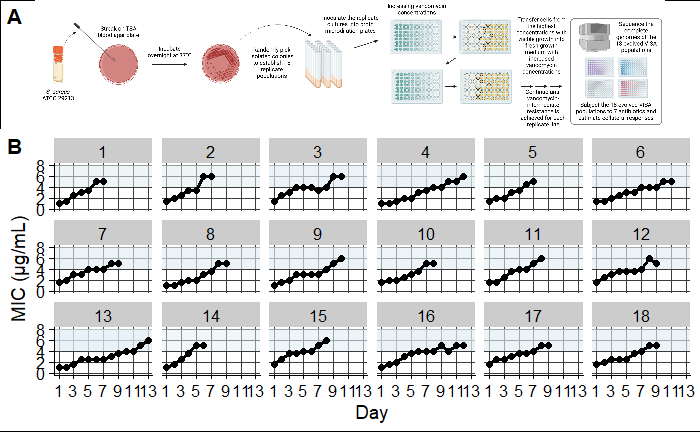

```r
figure_1 <- generate_figure_1(.x = vancomycin_MICs)

figure_1
```

# Genomic evolution

We used the *breseq* pipeline (v0.39.0) to identify mutations in the control and treated populations. The control lines evolved in TSB medium without vancomycin, whereas the treated lines evolved in TSB medium supplemented with vancomycin. We concatenated the *breseq* output files for each control and treated population, labeled “C1” through “C87” and “T1” through “T18”, respectively. We also manually curated the *breseq* output files to ensure that the mutations were correctly identified and annotated. Lastly, following Deatherage et al. 2017 and Card et al. 2021, for each mutation, we determined whether it “qualified” for further analyses based on the following criteria:

1. It was a nonsynonymous point mutation or small indel in a single gene.
2. An intergenic mutation within 150 bp upstream of the start of a gene.
3. A large deletion if at least one of the affected genes was also found to be mutated in another population.

Conversely, we excluded mutations from further analyses if they were:

1. Synonymous (does not affect the resulting amino acid sequence).
2. Multicopy elements (e.g., ribosomal RNA operons) that may result from gene conversions but cannot be fully resolved using short-read sequencing data.

We also include all mutations that were at or above 5% frequency in the populations given that each population had an average read coverage depth exceeding 100X. A total of *227* mutations qualify based upon these criteria in the vancomycin-evolved lines and *3585* mutations qualify in the control lines.

```r
mutations <- read_csv(
  file = "data/mutations.csv",
  show_col_types = FALSE
)

# Filter the mutations object by the presence of qualifying mutations.
qualifying_mutations <- mutations %>%
  filter(qualifying_mutation == "yes")

list(
  all_mutations = mutations,
  qualifying_mutations = qualifying_mutations
)
```

| id | population | vancomycin | evidence | position | qualifying_mutation | mutation_type | mutation | freq | annotation | gene | description |
| --- | --- | --- | --- | --- | --- | --- | --- | --- | --- | --- | --- |
| 1 | C1 | no | RA | 290 | yes | Nonsynonymous | G -> T | 0.062 | G97V (GGC -> GTC) | LNEJMEBC_00001 | hypothetical protein |
| 2 | C1 | no | RA | 10,788 | yes | Nonsynonymous | G -> T | 0.062 | G762V (GGT -> GTT) | tmp | tail tape measure protein |
| 3 | C1 | no | RA | 29,111 | yes | Nonsynonymous | T -> A | 0.125 | K222N (AAA -> AAT) | hisC1 | Histidinol-phosphate aminotransferase |
| 4 | C1 | no | RA | 59,569 | yes | Nonsynonymous | A -> G | 0.073 | N342S (AAT -> AGT) | pcrA | ATP-dependent DNA helicase PcrA |
| 5 | C1 | no | RA | 210,849 | yes | Nonsynonymous | C -> T | 0.068 | A64T (GCA -> ACA) | LNEJMEBC_00242 | hypothetical protein |
| 6 | C1 | no | RA | 218,739 | yes | Nonsynonymous | C -> A | 0.053 | A1016E (GCA -> GAA) | sasC | LPXTG-anchored repetitive surface protein SasC |
| 7 | C1 | no | RA | 250,012 | yes | Nonsynonymous | G -> T | 0.070 | A301S (GCA -> TCA) | acsA1 | Acetyl-coenzyme A synthetase |
| 8 | C1 | no | RA | 496,534 | yes | Nonsynonymous | G -> T | 0.083 | D624Y (GAT -> TAT) | LNEJMEBC_00500 | hypothetical protein |
| 9 | C1 | no | RA | 501,173 | yes | Nonsynonymous | A -> G | 0.061 | K136R (AAA -> AGA) | LNEJMEBC_00505 | hypothetical protein |
| 10 | C1 | no | RA | 524,332 | yes | Nonsense | C -> T | 0.111 | Q113* (CAA -> TAA) | LNEJMEBC_00527 | hypothetical protein |

[output cut: 990 more lines]

| id | population | vancomycin | evidence | position | qualifying_mutation | mutation_type | mutation | freq | annotation | gene | description |
| --- | --- | --- | --- | --- | --- | --- | --- | --- | --- | --- | --- |
| 1 | C1 | no | RA | 290 | yes | Nonsynonymous | G -> T | 0.062 | G97V (GGC -> GTC) | LNEJMEBC_00001 | hypothetical protein |
| 2 | C1 | no | RA | 10,788 | yes | Nonsynonymous | G -> T | 0.062 | G762V (GGT -> GTT) | tmp | tail tape measure protein |
| 3 | C1 | no | RA | 29,111 | yes | Nonsynonymous | T -> A | 0.125 | K222N (AAA -> AAT) | hisC1 | Histidinol-phosphate aminotransferase |
| 4 | C1 | no | RA | 59,569 | yes | Nonsynonymous | A -> G | 0.073 | N342S (AAT -> AGT) | pcrA | ATP-dependent DNA helicase PcrA |
| 5 | C1 | no | RA | 210,849 | yes | Nonsynonymous | C -> T | 0.068 | A64T (GCA -> ACA) | LNEJMEBC_00242 | hypothetical protein |
| 6 | C1 | no | RA | 218,739 | yes | Nonsynonymous | C -> A | 0.053 | A1016E (GCA -> GAA) | sasC | LPXTG-anchored repetitive surface protein SasC |
| 7 | C1 | no | RA | 250,012 | yes | Nonsynonymous | G -> T | 0.070 | A301S (GCA -> TCA) | acsA1 | Acetyl-coenzyme A synthetase |
| 8 | C1 | no | RA | 496,534 | yes | Nonsynonymous | G -> T | 0.083 | D624Y (GAT -> TAT) | LNEJMEBC_00500 | hypothetical protein |
| 9 | C1 | no | RA | 501,173 | yes | Nonsynonymous | A -> G | 0.061 | K136R (AAA -> AGA) | LNEJMEBC_00505 | hypothetical protein |
| 10 | C1 | no | RA | 524,332 | yes | Nonsense | C -> T | 0.111 | Q113* (CAA -> TAA) | LNEJMEBC_00527 | hypothetical protein |

[output cut: 990 more lines]

```
NA
```

The following code:

1. Generates a binary matrix representing the qualifying gene-level mutations in each evolutionary replicate. We use this matrix for subsequent analyses.
2. Calculates the average pairwise similarity within the vancomycin-adapted and the control lines. We then compare the average similarity between the two groups to determine if the vancomycin-adapted lines exhibit a higher degree of genomic parallelism than the control lines.
3. Performs a permutation test to evaluate the statistical significance of the observed difference between the vancomycin-adapted and control lines.

```r
binary_matrix <- generate_binary_matrix(.x = qualifying_mutations)
genomic_results <- perform_genomic_analysis(.x = binary_matrix)
```

We quantified the extent of genomic parallelism in the vancomycin-adapted lines and in the control lines by calculating Dice’s Similarity Coefficient (*S*) for each population pair, where:

$$S = \frac{2|X \cap
Y|}{|X|+|Y|}$$

$|X|$ and $|Y|$ represent the number of genes with qualifying mutations in each population, and $|X \cap Y|$ is the number of mutated genes in common between them. *S* therefore ranges from 0, when the pair share no mutations in common, to 1, when both have mutations in exactly the same set of genes (Deatherage et al., 2017; Card et al. 2021).

By default, the perform_genomic_analysis function will output a list containing two elements:

1. Average pairwise similarity within the vancomycin-treated group ($S_v \approx 0.0625$) and within the control group ($S_c \approx 0.0290$). In other words, two populations that independently evolved under vancomycin selection had, on average, *6.25%* of their mutated genes in common, whereas those that evolved under identical conditions, but without vancomycin, shared on average only *2.90%* of their mutated genes.
2. The difference between these averages ($\overline{S}_v - \overline{S}_c \approx 0.0335$) represents how much greater (on average) the vancomycin-adapted lines’ similarity is relative to the control lines. We expect that the vancomycin-adapted lines will exhibit a higher degree of genomic parallelism than the control lines.

```r
similarity <- genomic_results$similarity
names(similarity) <- c("Average pairwise similarity", "Difference in means")

head(similarity)
```

```
$`Average pairwise similarity`
```

| group_1 | group_2 | avg |
| --- | --- | --- |
| C | C | 0.02898652 |
| T | T | 0.06254139 |

```
$`Difference in means`
```

| difference |
| --- |
| 0.03355487 |

```
NA
```

To evaluate the statistical significance of the observed difference between the vancomycin-adapted and control lines, we generated a distribution under the null hypothesis that there is no difference between the two groups. To achieve this distribution, we permuted the population labels by resampling without replacement 10,000 times. For each permutation, we calculated the difference in $S_v$ and $S_c$. We then compared our observed difference to the null distribution of differences. The *p*-value is the proportion of permutations where the difference was greater than or equal to the observed difference.

```r
genomic_permutation_data <- genomic_results$permutation_results
significance <- genomic_results$significance

genomic_permutation_results <- list(
  ... = genomic_permutation_data,
  ... = significance
)

names(genomic_permutation_results) <- c("Permutation data", "Significance")

head(genomic_permutation_results)
```

```
$`Permutation data`
```

| control | treated | difference |
| --- | --- | --- |
| 0.02452860 | 0.02921209 | 4.683485e-03 |
| 0.02446243 | 0.02334663 | -1.115800e-03 |
| 0.02494500 | 0.02305716 | -1.887837e-03 |
| 0.02432101 | 0.02347030 | -8.507065e-04 |
| 0.02436465 | 0.03021697 | 5.852316e-03 |
| 0.02493217 | 0.02189134 | -3.040830e-03 |
| 0.02445934 | 0.02233876 | -2.120577e-03 |
| 0.02520562 | 0.02320211 | -2.003511e-03 |
| 0.02501890 | 0.02235656 | -2.662336e-03 |
| 0.02457821 | 0.02259903 | -1.979174e-03 |

[output cut: 990 more lines]

```
$Significance
[1] 0
```

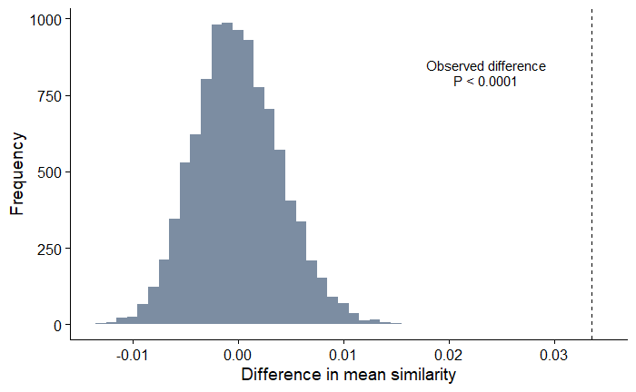

```r
figure_S1 <- genomic_permutation_data %>%
  ggplot(
    aes(x = difference)
  ) +
  geom_histogram(
    binwidth = 0.001,
    fill = "#7C8DA2"
  ) +
  geom_vline(
    xintercept = similarity[[2]]$difference,
    linetype = "dashed",
    color = "#000000"
  ) +
  annotate(
    geom = "text",
    x = similarity[[2]]$difference - 0.01,
    y = 850,
    label = "Observed difference",
    color = "#000000"
  ) +
  annotate(
    geom = "text",
    x = similarity[[2]]$difference - 0.01,
    y = 800,
    label = "P < 0.0001",
    color = "#000000"
  ) +
  xlab("Difference in mean similarity") +
  ylab("Frequency") +
  theme_cowplot() +
  theme(
    legend.position = "none",
    plot.background = element_rect(fill = "white")
  )

figure_S1
```

The permutation test showed that the vancomycin-adapted lines differ significantly in genomic parallelism relative to the control lines. However, this analysis does not specify which genes are associated with vancomycin selection. To identify these genes, we perform multivariate logistic regression with the treatment status (i.e., vancomycin or no vancomycin) as the outcome and qualifying gene-level mutations as the predictors. We only include in our model qualifying mutations that occur in at least three populations resulting in 446 gene-level mutations. Because there are only 18 outcome events (i.e., populations that evolved under vancomycin selection) and 446 predictors, we use L1 and L2 penalization on model coefficients to avoid overfitting.

We perform this procedure in two steps. First, we determine the number of iterations needed to achieve convergence of the model coefficient estimates. Second, we run the logistic regression model with the updated number of iterations.

| gene | coef_mean | coef_SE | OR_mean | OR_SE | coef_lower_CI | coef_upper_CI | OR_lower_CI | OR_upper_CI |
| --- | --- | --- | --- | --- | --- | --- | --- | --- |
| atl1 | 0.49642019 | 0.012636929 | 1.6743714 | 0.019902064 | 0.47165181 | 0.52118857 | 1.6026393 | 1.6840280 |
| ebh | -0.12093580 | 0.005649797 | 0.8896187 | 0.005026086 | -0.13200940 | -0.10986220 | 0.8763328 | 0.8959576 |
| folE2 | 0.05940553 | 0.006415189 | 1.0669456 | 0.007393892 | 0.04683176 | 0.07197930 | 1.0479457 | 1.0746331 |
| liaF | 1.09849845 | 0.010143863 | 3.0361034 | 0.028759047 | 1.07861647 | 1.11838042 | 2.9406083 | 3.0598944 |
| lyrA | 0.05406962 | 0.006119298 | 1.0607513 | 0.007010225 | 0.04207579 | 0.06606344 | 1.0429735 | 1.0682945 |
| mgrA | -0.05251163 | 0.004545930 | 0.9512307 | 0.004173990 | -0.06142165 | -0.04360160 | 0.9404266 | 0.9573353 |
| pdhC2 | 0.15169050 | 0.011046423 | 1.1822201 | 0.013717756 | 0.13003951 | 0.17334149 | 1.1388734 | 1.1892722 |
| rpsU | 0.82663502 | 0.011576842 | 2.3225605 | 0.025393119 | 0.80394442 | 0.84932563 | 2.2343367 | 2.3380696 |
| srrA | 0.15642514 | 0.010102198 | 1.1846226 | 0.012384019 | 0.13662483 | 0.17622544 | 1.1463980 | 1.1927069 |
| stp | 0.20189761 | 0.009836435 | 1.2384304 | 0.012031117 | 0.18261820 | 0.22117702 | 1.2003560 | 1.2475443 |

[output cut: 5 more lines]

```
NA
```

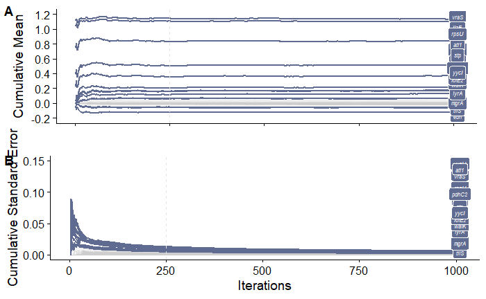

```r
regression_and_plots <- perform_regression_and_plots(.x = binary_matrix)
regression_summary <- regression_and_plots[[1]][[1]]
OR_matrix <- regression_and_plots[[1]][[2]]

# Plots
convergence_plots <- regression_and_plots[[2]]

list(
  convergence_plots = convergence_plots,
  regression_summary = regression_summary
)
```

```
$...

$...

$...
```

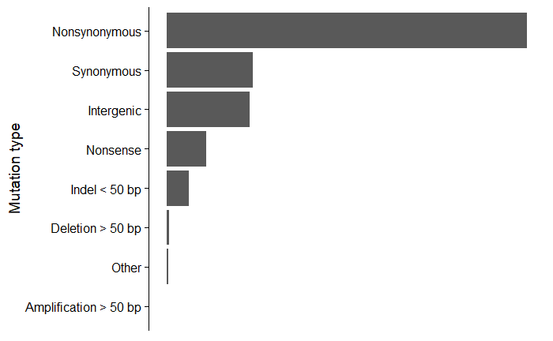

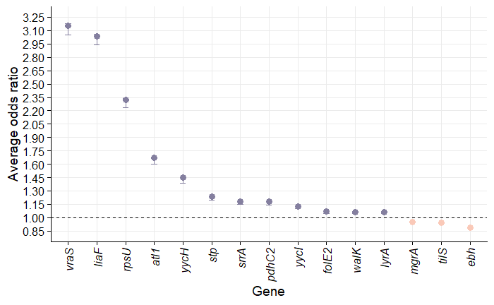

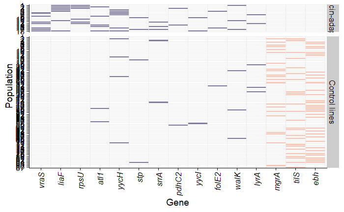

```r
figure_2A <- mutations %>%
  ggplot(
    aes(x = fct_infreq(mutation_type))
  ) +
  geom_bar() +
  xlab("Mutation type") +
  ylab("Count") +
  scale_x_discrete(limits = rev) +
  theme_cowplot() +
  theme(
    plot.background = element_rect(fill = "white"),
    axis.title.x = element_blank(),
    axis.text.x = element_blank(),
    axis.ticks.x = element_blank(),
    axis.line.x = element_blank()
  ) +
  coord_flip()

figure_2B <- generate_OR_plot(
  .x = regression_summary,
  .y = OR_matrix
)

figure_2C <- generate_heatmap_plot(
  .x = regression_summary,
  .y = OR_matrix
)

list(
  ... = figure_2A,
  ... = figure_2B,
  ... = figure_2C
)
```

We then perform a Bayesian latent class analysis (BLCA) to group lines based on their mutation profiles

```r
perform_blca(
  .x = regression_and_plots,
  iterations = 1000
)
```

[output not shown]

[output cut: 1945 more lines]

[output not shown]

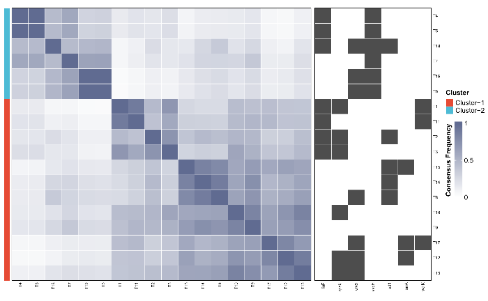

```r
# The best number of clusters was 2 based on AIC
figure_S2_pdf <- image_read_pdf(
  "Figures/cluster_plots/CC_Genomic_AIC_treatedOnly_K2.pdf",
  density = 300
)

figure_S2_rasterized <- rasterGrob(
  as.raster(figure_S2_pdf),
  interpolate = TRUE
)

# Convert figure_4 to ggplot object
figure_S2 <- ggplot() +
  annotation_custom(grob = figure_S2_rasterized) +
  theme_void()

figure_S2
```

```r
# Contingency table for yycH versus rpsU
yycH_versus_rpsU <- matrix(c(0, 6, 6, 6), nrow = 2, byrow = TRUE)
rownames(yycH_versus_rpsU) <- c("rpsU_Present", "rpsU_Absent")
colnames(yycH_versus_rpsU) <- c("yycH_Present", "yycH_Absent")

# Contingency table for WalKR regulon versus rpsU
regulon_versus_rpsU <- matrix(c(2, 4, 12, 0), nrow = 2, byrow = TRUE)
rownames(regulon_versus_rpsU) <- c("rpsU_Present", "rpsU_Absent")
colnames(regulon_versus_rpsU) <- c("regulon_Present", "regulon_Absent")

list(
  ... = fisher.test(yycH_versus_rpsU),
  ... = fisher.test(regulon_versus_rpsU)
)
```

```
$...

    Fisher's Exact Test for Count Data

data:  yycH_versus_rpsU
p-value = 0.05371
alternative hypothesis: true odds ratio is not equal to 1
95 percent confidence interval:
 0.000000 1.377046
sample estimates:
odds ratio
         0


$...

    Fisher's Exact Test for Count Data

data:  regulon_versus_rpsU
p-value = 0.004902
alternative hypothesis: true odds ratio is not equal to 1
95 percent confidence interval:
 0.000000 0.508626
sample estimates:
odds ratio
         0
```

# S. aureus populations exhibit variable collateral sensitivity to first-line therapies after vancomycin exposure

```r
# Data report the MICs of 8 antibiotics -- cefazolin, clindamycin, daptomycin,
# gentamycin, meropenem, nafcillin, trimethoprim-sulfamethoxazole, and
# vancomycin -- on the MSSA ancestral clone ATCC 29213 and evolved
# vancomycin-intermediate populations.

collateral_MICs <- read_csv(
  file = "data/collateral_drug_MICs.csv",
  show_col_types = FALSE
)
```

```r
# Calculates collateral responses
collateral_responses <- calculate_collateral_responses(.x = collateral_MICs)

# Calculates summary statistics
CR_summary_stats <- perform_summary_stats(.x = collateral_responses)

list(
  collateral_responses = collateral_responses,
  collateral_responses_summary = CR_summary_stats
)
```

| population | replicate | antibiotic | MIC | CR |
| --- | --- | --- | --- | --- |
| 1 | 1 | CFZ | 0.25000 | -0.5849625 |
| 1 | 2 | CFZ | 0.25000 | -0.5849625 |
| 1 | 3 | CFZ | 0.25000 | -0.5849625 |
| 2 | 1 | CFZ | 0.50000 | 0.4150375 |
| 2 | 2 | CFZ | 0.50000 | 0.4150375 |
| 2 | 3 | CFZ | 0.50000 | 0.4150375 |
| 3 | 1 | CFZ | 0.75000 | 1.0000000 |
| 3 | 2 | CFZ | 0.75000 | 1.0000000 |
| 3 | 3 | CFZ | 0.75000 | 1.0000000 |
| 4 | 1 | CFZ | 0.25000 | -0.5849625 |

[output cut: 422 more lines]

| antibiotic | population | mean_MIC | mean_CR | state |
| --- | --- | --- | --- | --- |
| CFZ | 1 | 0.25000000 | -0.5849625 | -1 |
| CFZ | 10 | 0.50000000 | 0.1383458 | 1 |
| CFZ | 11 | 0.50000000 | 0.0000000 | 0 |
| CFZ | 12 | 0.58333333 | 0.3333333 | 1 |
| CFZ | 13 | 0.75000000 | 1.0000000 | 1 |
| CFZ | 14 | 0.50000000 | 0.4150375 | 1 |
| CFZ | 15 | 0.45833333 | 0.2766917 | 1 |
| CFZ | 16 | 0.25000000 | -0.5849625 | -1 |
| CFZ | 17 | 0.37500000 | -0.2766917 | -1 |
| CFZ | 18 | 0.50000000 | 0.0000000 | 0 |

[output cut: 134 more lines]

```
NA
```

```r
figure_3B <- CR_summary_stats %>%
  ggplot(
    aes(
      y = population,
      x = antibiotic,
      fill = mean_CR
    )
  ) +
  geom_tile(color = "black") +
  scale_fill_gradient2(
    low = "#1a4891",
    mid = "white",
    high = "#a01415",
    midpoint = 0
  ) +
  scale_y_discrete(
    limits = rev(
      factor(
        seq(1, 18, 1)
      )
    )
  ) +
  scale_x_discrete(
    limits =
      factor(
        c("DAP", "VAN", "CFZ", "SXT", "CLI", "MEM", "NAF", "GEN")
      ),
      position = "top"
  ) +
  ylab("Population") +
  xlab("Antibiotic") +
  theme_cowplot() +
  theme(
    legend.position = "bottom",
    legend.title = element_blank(),
    legend.ticks = element_blank(),
    plot.background = element_rect(fill = "white"),
    panel.background = element_blank(),
    axis.line = element_blank(),
    axis.ticks = element_blank()
  )

figure_3C <- generate_CR_plot(
  .x = CR_summary_stats
)
```

We used Mann-Whitney U tests to compare the collateral response values of the evolved populations to the ancestral population for each antibiotic.

```r
mw_stats <- map(
  unique(collateral_MICs$antibiotic),
  ~ perform_MW_test(
    .data = collateral_MICs,
    ab = .x
  )
)

names(mw_stats) <- unique(collateral_MICs$antibiotic)

list(mw_stats)
```

```
[[1]]
[[1]]$CFZ

    Wilcoxon rank sum test

data:  MIC by population
W = 55, p-value = 0.3321
alternative hypothesis: true location shift is not equal to 0


[[1]]$CLI

    Wilcoxon rank sum test

data:  MIC by population
W = 108, p-value = 0.01754
alternative hypothesis: true location shift is not equal to 0


[[1]]$DAP

    Wilcoxon rank sum test

data:  MIC by population
W = 4, p-value = 0.0001314
alternative hypothesis: true location shift is not equal to 0


[[1]]$GEN

    Wilcoxon rank sum test

data:  MIC by population
W = 97.5, p-value = 0.1506
alternative hypothesis: true location shift is not equal to 0


[[1]]$MEM

    Wilcoxon rank sum test
```

[output cut: 16 more lines]

```

    Wilcoxon rank sum test

data:  MIC by population
W = 44, p-value = 0.04432
alternative hypothesis: true location shift is not equal to 0


[[1]]$VAN

    Wilcoxon rank sum test

data:  MIC by population
W = 0, p-value = 3.849e-05
alternative hypothesis: true location shift is not equal to 0
```

```r
# Extract p-values from the mw_stats object and put into a dataframe
mw_pvals <- c()
for (i in 1:length(mw_stats)) {
  mw_pvals <- rbind(
    mw_pvals,
    data.frame(
      antibiotic = names(mw_stats)[i],
      p_value = mw_stats[[i]]$p.value
    )
  )
}

mw_p_adjusted <- p.adjust(
  p = mw_pvals$p_value,
  method = "BH"
)

names(mw_p_adjusted) <- mw_pvals$antibiotic

mw_p_adjusted
```

```
         CFZ          CLI          DAP          GEN          MEM          NAF          SXT          VAN
0.3794910158 0.0467799105 0.0005256211 0.2080483531 0.4946242449 0.2080483531 0.0886339265 0.0003079510
```

We can combine the collateral response and genomic data obtained from each population to evaluate whether genomic differences that evolved during vancomycin adaptation shape drug tradeoffs.

```r
biserial_results <- perform_biserial_correlation(.data = CR_summary_stats)


regulon_p_adjusted <- p.adjust(
  p = map_dbl(biserial_results$regulon_results, ~ .x$p.value),
  method = "BH"
)

rpsU_p_adjusted <- p.adjust(
  p = map_dbl(biserial_results$rpsU_results, ~ .x$p.value),
  method = "BH"
)

list(
  biserial_results = biserial_results,
  regulon_p_adjusted = regulon_p_adjusted,
  yycHI_p = biserial_results$yycHI_results$NAF$p.value,
  rpsU_p_adjusted = rpsU_p_adjusted
)
```

```
$biserial_results
$biserial_results$regulon_results
$biserial_results$regulon_results$CFZ

    Pearson's product-moment correlation

data:  mean_CR and as.numeric(mutated)
t = -2.1789, df = 14, p-value = 0.04692
alternative hypothesis: true correlation is not equal to 0
95 percent confidence interval:
 -0.79949543 -0.01001952
sample estimates:
       cor
-0.5032255


$biserial_results$regulon_results$MEM

    Pearson's product-moment correlation

data:  mean_CR and as.numeric(mutated)
t = -1.9766, df = 14, p-value = 0.06812
alternative hypothesis: true correlation is not equal to 0
95 percent confidence interval:
 -0.78178927  0.03721915
sample estimates:
       cor
-0.4671041


$biserial_results$regulon_results$NAF

    Pearson's product-moment correlation

data:  mean_CR and as.numeric(mutated)
t = -3.3833, df = 14, p-value = 0.004458
alternative hypothesis: true correlation is not equal to 0
95 percent confidence interval:
 -0.8753694 -0.2621456
sample estimates:
```

[output cut: 131 more lines]

```
-0.2120288




$regulon_p_adjusted
       CFZ        MEM        NAF        GEN
0.09083165 0.09083165 0.01783375 0.25585266

$yycHI_p
[1] 0.03724054

$rpsU_p_adjusted
       CFZ        MEM        NAF        GEN
0.06672216 0.06672216 0.03785965 0.39830806
```

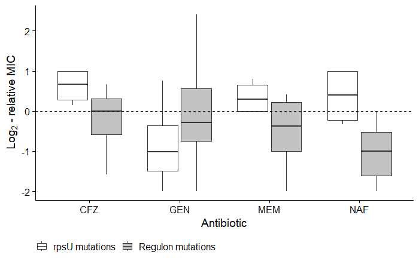

```r
figure_3D <- CR_summary_stats %>%
  filter(antibiotic %in% c("CFZ", "MEM", "NAF", "GEN")) %>%
  # Remove populations that have both regulon and rpsU mutations
  filter(!population %in% c(1, 2)) %>%
  mutate(
    regulon = ifelse(
      population %in% c(4, 5, 6, 7, 8, 9, 11, 14, 15, 16, 17, 18),
      "1",
      "0"
    )
  ) %>%
  ggplot(
    aes(
      x = antibiotic,
      y = mean_CR,
      fill = regulon
    )
  ) +
  geom_boxplot(outlier.shape = 1) +
  geom_hline(
    yintercept = 0,
    linetype = "dashed",
    color = "#000000"
  ) +
  xlab("Antibiotic") +
  ylab(
    expression(
      "Log"[2] ~ "-" ~ "relative MIC"
    )
  ) +
  scale_fill_manual(
    labels = c("rpsU mutations", "Regulon mutations"),
    values = c("#FFFFFF", "#C2C2C2")
  ) +
  theme_cowplot() +
  theme(
    legend.position = "bottom",
    plot.background = element_rect(fill = "white"),
    legend.title = element_blank()
  )

figure_3D
```

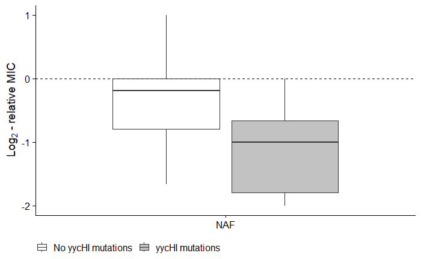

```r
figure_3E <- CR_summary_stats %>%
  filter(antibiotic == "NAF") %>%
  mutate(
    mutation = ifelse(
      population %in% c(4, 5, 6, 7, 9, 16, 18),
      "1",
      "0"
    )
  ) %>%
  ggplot(
    aes(
      x = antibiotic,
      y = mean_CR,
      fill = mutation
    )
  ) +
  geom_boxplot(outlier.shape = 1) +
  geom_hline(
    yintercept = 0,
    linetype = "dashed",
    color = "#000000"
  ) +
  xlab("Antibiotic") +
  ylab(
    expression(
      "Log"[2] ~ "-" ~ "relative MIC"
    )
  ) +
  scale_fill_manual(
    labels = c("No yycHI mutations", "yycHI mutations"),
    values = c("#FFFFFF", "#C2C2C2")
  ) +
  theme_cowplot() +
  theme(
    legend.position = "bottom",
    plot.background = element_rect(fill = "white"),
    legend.title = element_blank(),
    axis.title.x = element_blank()
  )

figure_3E
```

```r
NA
NA
```

Now, we first estimate the bootstrap distribution of collateral response scores (CRS) for each antibiotic and mutational pathway. The CSS metric evaluates the net collateral effect of antibiotic exposure by integrating both the magnitude and direction of changes in MIC, providing a robust metric for evaluating the likelihood of collateral sensitivity or resistance. This score is amenable to statistical investigation and provides a standardized way of reporting this information for clinical decision-making. The CSS is defined as,

$$\text{CSS} = \frac{\frac{1}{N}
\sum_{i=1}^{N} \log_2\left
(\frac{\mathrm{MIC}_{i,\text{evolved}}}{\mathrm{MIC}_
{i,\text{ancestor}}}\right)}{\max_{1 \leq i \leq N} \left|\log_2\left
(\frac{\mathrm{MIC}_{i,\text{evolved}}}{\mathrm{MIC}_
{i,\text{ancestor}}}\right)\right|}$$

where *N* is the number of replicate populations, *i*.

| CSS | replicate | antibiotic | lower_perc | upper_perc | point_est |
| --- | --- | --- | --- | --- | --- |
| 0.047932291 | 1 | CFZ | -0.2804151 | 0.3279932 | 0.03569732 |
| 0.017097539 | 2 | CFZ | -0.2804151 | 0.3279932 | 0.03569732 |
| 0.315225521 | 3 | CFZ | -0.2804151 | 0.3279932 | 0.03569732 |
| -0.089302685 | 4 | CFZ | -0.2804151 | 0.3279932 | 0.03569732 |
| 0.070920283 | 5 | CFZ | -0.2804151 | 0.3279932 | 0.03569732 |
| 0.195739323 | 6 | CFZ | -0.2804151 | 0.3279932 | 0.03569732 |
| -0.177103132 | 7 | CFZ | -0.2804151 | 0.3279932 | 0.03569732 |
| -0.162713498 | 8 | CFZ | -0.2804151 | 0.3279932 | 0.03569732 |
| 0.211058854 | 9 | CFZ | -0.2804151 | 0.3279932 | 0.03569732 |
| 0.015852274 | 10 | CFZ | -0.2804151 | 0.3279932 | 0.03569732 |

[output cut: 790 more lines]

| CSS | replicate | cluster | lower_perc | upper_perc | point_est |
| --- | --- | --- | --- | --- | --- |
| 0.190767279 | 1 | 0 | 0.02342799 | 0.3347050 | 0.1827362 |
| 0.220481582 | 2 | 0 | 0.02342799 | 0.3347050 | 0.1827362 |
| 0.155118919 | 3 | 0 | 0.02342799 | 0.3347050 | 0.1827362 |
| 0.132401224 | 4 | 0 | 0.02342799 | 0.3347050 | 0.1827362 |
| 0.155365904 | 5 | 0 | 0.02342799 | 0.3347050 | 0.1827362 |
| 0.236663646 | 6 | 0 | 0.02342799 | 0.3347050 | 0.1827362 |
| 0.220748318 | 7 | 0 | 0.02342799 | 0.3347050 | 0.1827362 |
| 0.130061072 | 8 | 0 | 0.02342799 | 0.3347050 | 0.1827362 |
| 0.201992859 | 9 | 0 | 0.02342799 | 0.3347050 | 0.1827362 |
| 0.262696212 | 10 | 0 | 0.02342799 | 0.3347050 | 0.1827362 |

[output cut: 190 more lines]

| CSS | replicate | antibiotic | cluster | lower_perc | upper_perc | point_est | antibiotic_numeric | y_offset |
| --- | --- | --- | --- | --- | --- | --- | --- | --- |
| 0.8333333333 | 1 | CFZ | 0 | 0.3537594 | 1.00000000 | 0.617919792 | 1 | 0.8 |
| 0.4512531249 | 2 | CFZ | 0 | 0.3537594 | 1.00000000 | 0.617919792 | 1 | 0.8 |
| 0.4025062499 | 3 | CFZ | 0 | 0.3537594 | 1.00000000 | 0.617919792 | 1 | 0.8 |
| 0.6179197916 | 4 | CFZ | 0 | 0.3537594 | 1.00000000 | 0.617919792 | 1 | 0.8 |
| 0.6179197916 | 5 | CFZ | 0 | 0.3537594 | 1.00000000 | 0.617919792 | 1 | 0.8 |
| 0.8333333333 | 6 | CFZ | 0 | 0.3537594 | 1.00000000 | 0.617919792 | 1 | 0.8 |
| 0.6666666667 | 7 | CFZ | 0 | 0.3537594 | 1.00000000 | 0.617919792 | 1 | 0.8 |
| 0.8537593748 | 8 | CFZ | 0 | 0.3537594 | 1.00000000 | 0.617919792 | 1 | 0.8 |
| 0.3537593748 | 9 | CFZ | 0 | 0.3537594 | 1.00000000 | 0.617919792 | 1 | 0.8 |
| 0.6179197916 | 10 | CFZ | 0 | 0.3537594 | 1.00000000 | 0.617919792 | 1 | 0.8 |

[output cut: 990 more lines]

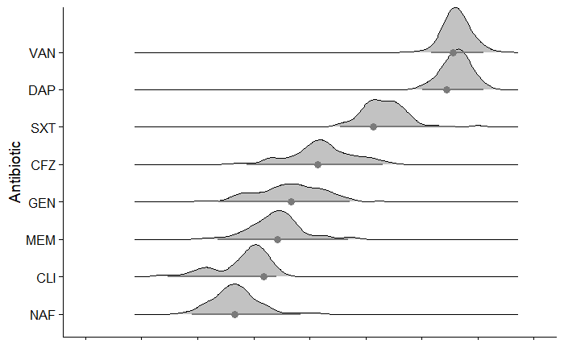

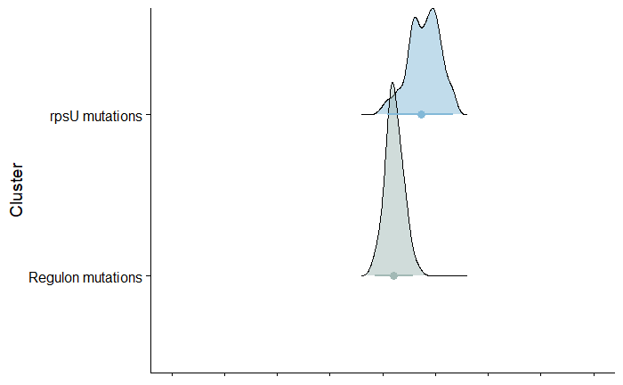

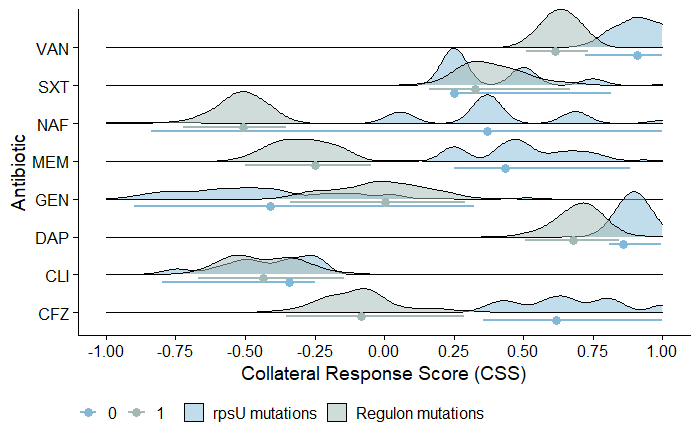

```r
css_bootstrap_results <- perform_bootstrap_and_plot_css(
  .x = CR_summary_stats,
  iterations = 100
)

css_bootstrap_results
```